# Session 4 — Interaction and Effect Modification

Product terms · simple slopes · centring · emtrends · categorical interactions · additive scale · testing · Lab 4

Community Medicine Workshop

## Where we are

- Sessions 1 to 3: the **shape** of one predictor’s effect
- Today: when the **effect of one variable depends on another** (**effect modification**)
- By the end you can:
  - fit and read a **product term**
  - compute **simple slopes** with `emtrends`
  - **centre** a variable to interpret main effects
  - interpret an interaction on the **additive and multiplicative scale**
  - avoid the **subgroup p-value trap**

# Topic 1 — Continuous × continuous

## Salt and age

```r
m_i <- lm(sbp ~ salt * age + bmi + activity + sex + smoker, data = ncd)
round(summary(m_i)$coefficients["salt:age", ], 4)
```

```
  Estimate Std. Error    t value   Pr(>|t|)
    0.0502     0.0052     9.6286     0.0000
```

`salt * age` = `salt + age + salt:age`. The interaction is **+0.050 mmHg per g/day per year of age** (p < 0.001): **the effect of salt grows 0.05 mmHg per g/day for every year of age**.

## Simple slopes

```r
b <- coef(m_i)
round(sapply(c(30, 45, 60), function(a) b[["salt"]] + a * b[["salt:age"]]), 2)
```

```
[1] -0.01  0.74  1.49
```

```r
emtrends(m_i, ~ age, var = "salt", at = list(age = c(30, 45, 60)))
```

```
 age salt.trend     SE   df lower.CL upper.CL
  30    -0.0136 0.1000 3992   -0.210    0.183
  45     0.7391 0.0727 3992    0.597    0.882
  60     1.4917 0.1130 3992    1.270    1.713

Results are averaged over the levels of: sex, smoker
Confidence level used: 0.95
```

- **Age 30**: no effect of salt (−0.01 mmHg per g/day)
- **Age 45**: +0.74; **age 60**: +1.49, twice as much
- **“The effect of salt”** has **no single value**: it depends on age
- `emtrends` gives the slopes with **CIs** at chosen ages

## Plot it

```r
g <- expand.grid(salt = seq(3, 18, 1), age = c(30, 45, 60)) |> mutate(bmi = mean(ncd$bmi), activity = mean(ncd$activity), sex = factor("Male", levels = levels(ncd$sex)), smoker = 0)
g$fit <- predict(m_i, g)
ggplot(g, aes(salt, fit, colour = factor(age))) + geom_line(linewidth = 1.3) + scale_colour_manual(values = c(col_green, col_blue, col_red)) + labs(x = "Salt (g/day)", y = "Predicted SBP (mmHg)", colour = "Age")
```

**Fan-shaped lines**: flat at 30, steeper at 60. An interaction shows as **non-parallel lines**.

## Plot it

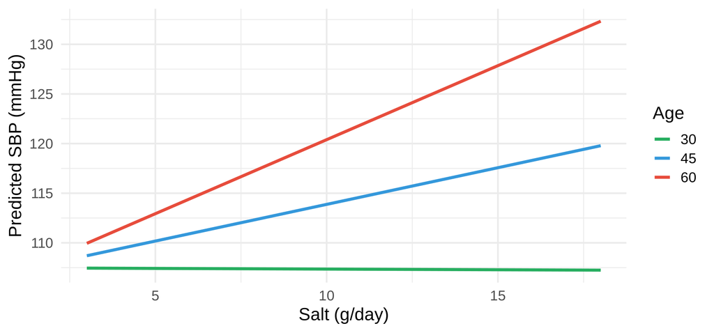

## Centring

```r
ncd <- ncd |> mutate(age45 = age - 45)
m_c <- lm(sbp ~ salt * age45 + bmi + activity + sex + smoker, data = ncd)
round(c(salt_uncentred = coef(m_i)[["salt"]], salt_centred = coef(m_c)[["salt"]]), 3)
```

```
salt_uncentred   salt_centred
        -1.519          0.739
```

With an interaction, the **“main effect” of salt is the effect when age = 0**: meaningless. **Centre** age (here at 45) and the salt coefficient becomes the effect **at age 45** (0.74). The **interaction** coefficient does **not** change.

# Topic 2 — Categorical and scales

## Smoking × sex for CVD risk

```r
g_ss <- glm(cvd10 ~ age + bmi + I(bmi^2) + sex * smoker, data = ncd, family = binomial)
round(summary(g_ss)$coefficients["sexMale:smoker", ], 3)
```

```
  Estimate Std. Error    z value   Pr(>|z|)
     0.824      0.304      2.714      0.007
```

```r
emmeans(g_ss, ~ smoker | sex, type = "response") |> pairs(reverse = TRUE)
```

```
sex = Female:
 contrast          odds.ratio    SE  df null z.ratio p.value
 smoker1 / smoker0      0.993 0.260 Inf    1  -0.026  0.9790

sex = Male:
 contrast          odds.ratio    SE  df null z.ratio p.value
 smoker1 / smoker0      2.264 0.348 Inf    1   5.321 <0.0001

Tests are performed on the log odds ratio scale
```

Smoking: **OR about 1.0 in women** and **2.3 in men**. The interaction term (log-OR 0.82, **p = 0.007**) tests whether the two odds ratios **differ**.

## Additive scale

```r
nd <- expand.grid(sex = factor(c("Female", "Male"), levels = levels(ncd$sex)), smoker = c(0, 1), age = 50, bmi = 25)
nd$risk <- round(100 * predict(g_ss, nd, type = "response"), 1)
nd
```

```
     sex smoker age bmi risk
1 Female      0  50  25  4.1
2   Male      0  50  25  5.1
3 Female      1  50  25  4.0
4   Male      1  50  25 10.8
```

- Risk (%) for a 50-year-old with BMI 25: women **4.1 vs 4.0**; men **5.1 vs 10.8**
- Risk difference: about **0** in women, **5.7 percentage points** in men
- An interaction on the **ratio (multiplicative)** scale and on the **additive** scale can **differ**; public health decisions use the **additive** scale (**absolute risk**)
- Always show **predicted risks**, not only odds ratios

# Topic 3 — Testing and caution

## The subgroup p-value trap

“Smoking is **significant in men** (p < 0.001) but **not in women** (p = 0.98), so sex **modifies** the effect.” **This is not a valid test.** A difference in **significance** is not a **significant difference**. Test the **interaction term** (here p = 0.007), and show both **estimates with CIs**.

## Good practice

1. **Pre-specify** a few plausible interactions (from theory)
2. Test the **interaction term**, then report **stratum-specific estimates** with CIs
3. Interactions need **a lot more data** than main effects (roughly **four times**, for equal-sized groups): do not expect power
4. **Many** interactions tried = **false positives**: report how many you tested
5. Plot **predictions**; centre continuous variables

## 🔧 Switch to R — Lab 4

**File:** `curves-workshop/labs/lab4_interaction.R`

- salt × age: coefficient, simple slopes, `emtrends`
- centring and a plot of predictions
- smoking × sex: odds ratios within sex, additive scale

**Time:** 40 minutes · answer the Q questions in the comments

## Self-check quiz (1/5)

In the model with salt * age the interaction coefficient is 0.05. What does it mean?

- Salt raises SBP by 0.05 mmHg per g/day, whatever the age of each adult
- Each year of age adds about 0.05 mmHg to the effect of 1 g/day of salt
- Salt and age together explain 5% of the variance in blood pressure
- The effect of salt is 0.05 mmHg at the average age of the sample

## Self-check quiz (2/5)

After age is centred at 45, the salt coefficient changes. Why?

- The centring changes the interaction coefficient as well as the main one
- The centred model fits better, so all the coefficients are re-estimated
- Salt is rescaled by the standard deviation of age
- It now shows the effect of salt at age 45, instead of at age 0

## Self-check quiz (3/5)

Smoking is clearly harmful in men (OR 2.3) but not in women (OR 1.0). Does this prove effect modification?

- No: test the interaction term, not the p-values within each sex
- Yes, since the effect is significant in one subgroup and not the other
- Yes, because the two odds ratios differ by more than a whole unit
- No, because effect modification needs a randomised trial to be shown

## Self-check quiz (4/5)

Predicted 10-year risk for smokers vs non-smokers: men 10.8% vs 5.1%, women 4.0% vs 4.1%. What are the risk differences for smoking?

- About 2.1 percentage points in men and 4.0 percentage points in women
- About 2.3 percentage points in men and 1.0 percentage points in women
- About 5.7 percentage points in men and close to zero in women
- About 10.8 percentage points in men and 4.0 percentage points in women

## Self-check quiz (5/5)

Why is a study often underpowered for an interaction even when it has power for the main effect?

- Interactions need a continuous variable, which loses information in the study
- The interaction compares subgroup effects, so its variance is larger
- The main effect uses all the data, while the interaction uses none of it
- Software reduces the sample size by the number of product terms in the model

## Score and take-home

**Your score:**

- `a * b` = `a + b + a:b`; the interaction = **difference in effects**
- **Simple slopes** with `emtrends`/`emmeans`; **plot** non-parallel lines
- **Centre** so that main effects mean something
- Show **absolute risks** (additive scale) as well as ORs
- Test the **interaction term**, not subgroup p-values; **pre-specify**

**Next:** Session 5: choosing, checking and reporting